# Genomic2DTK - In depth tutorial

Nicolas Chanard

2022-12-07

This package provides a set of functions useful in the analysis of 3D genomic interactions. It includes the import of standard HiC data formats into R and HiC normalisation procedures. The main objective of this package is to improve the visualization and quantification of the analysis of HiC contacts through aggreagtion.

# Requirements

## Installation

```r
remotes::install_github("NChanard/Genomic2DTK")
```

## Load library

```r
library(Genomic2DTK)
```

# Test dataset

## Description

Data were obtained from *Drosophila melanogaster S2 cells*.  
1. HiC test dataset Directly downloaded from the [4DN](https://data.4dnucleome.org) platform.  
* Control Condition  
* Heat Shock Condition  
2. Genomic coordinates:  
* ChIPseq peaks of Beaf-32 protein in wild type cells (GSM1278639).  
* Reference annotation data for TSS from the UCSC data base.  
* TAD annotations from TAD calling on HiC data in wild type ([F. Ramirez, 2018](https://doi.org/10.1038/s41467-017-02525-w)).

## 1 Genomic 3D structure

For a test, download HiC data in .hic format (Juicer) and .mcool format (HiCExplorer)

### Temp directory preparation

```r
options(timeout = 3600)
temp.dir <- file.path(tempdir(), "HIC_DATA")
dir.create(temp.dir)
```

```r
### Control condition (.hic File)
Hic.url <- "https://4dn-open-data-public.s3.amazonaws.com/fourfront-webprod/wfoutput/7386f953-8da9-47b0-acb2-931cba810544/4DNFIOTPSS3L.hic"
HicOutput.pth <- file.path(temp.dir, "Control_HIC.hic")
download.file(Hic.url, HicOutput.pth, method = 'curl', extra = '-k')
```

```r
### Heat shock condition (.mcool File)
Mcool.url <- "https://4dn-open-data-public.s3.amazonaws.com/fourfront-webprod/wfoutput/4f1479a2-4226-4163-ba99-837f2c8f4ac0/4DNFI8DRD739.mcool"
McoolOutput.pth <- file.path(temp.dir, "HeatShock_HIC.mcool")
download.file(Mcool.url, McoolOutput.pth, method = "curl", extra = "-k")
```

## 2 Genomic location and annotation data

These kind of data can be imported in R with [rtracklayer](https://bioconductor.org/packages/release/bioc/html/rtracklayer.html) package.

### ChIPseq peaks of Beaf-32 protein

```r
data("Beaf32_Peaks.gnr")
```

**View**

| seq | start | end | strand | name | score |
| --- | --- | --- | --- | --- | --- |
| 2L | 35594 | 35725 | * | Beaf32_2 | 76 |
| 2L | 47296 | 47470 | * | Beaf32_3 | 44 |
| 2L | 65770 | 65971 | * | Beaf32_5 | 520 |

### TSS annontation

```r
data("TSS_Peaks.gnr")
```

**View**

| seq | start | end | strand | name | class |
| --- | --- | --- | --- | --- | --- |
| 2L | 71757 | 71757 | + | FBgn0031213 | active |
| 2L | 76348 | 76348 | + | FBgn0031214 | inactive |
| 2L | 106903 | 106903 | + | FBgn0005278 | active |

### TADs annotation

```r
data("TADs_Domains.gnr")
```

**View**

| seq | start | end | strand | name | score | class |
| --- | --- | --- | --- | --- | --- | --- |
| 2L | 73104 | 94543 | * | Tad_1 | 3 | active |
| 2L | 94544 | 102930 | * | Tad_2 | 8 | active |
| 2L | 102931 | 121473 | * | Tad_3 | 8 | active |

## Additional genome informations

Required genomic informations used by the functions during the entire pipeline are a data.frame containing chromosomes names and sized and the binSize, corresponding to the HiC matrices at the same resolution.

```r
seqlengths.num <- c('2L'=23513712, '2R'=25286936)
chromSize.dtf  <- data.frame(
    seqnames   = names(seqlengths.num ),
    seqlengths = seqlengths.num
    )
binSize.num <- 1000
```

# 1 Import HiC

## A Import

```r
HiC_Ctrl.cmx_lst <- ImportHiC(
        file.pth    = HicOutput.pth,
        res.num     = 1000,
        chrom_1.chr = c("2L", "2L", "2R"),
        chrom_2.chr = c("2L", "2R", "2R")
)
```

```r
HiC_HS.cmx_lst <- ImportHiC(
        file.pth    = McoolOutput.pth,
        res.num     = 1000,
        chrom_1.chr = c("2L", "2L", "2R"),
        chrom_2.chr = c("2L", "2R", "2R")
)
```

### HiC data format: ContactMatrix list (cmx_lst) structure

Each element of the list corresponds to a ContactMatrix object (dgCMatrix object, sparse matrix format) storing contact frequencies for one chromosomes (cis-interactions, ex: “2L_2L”) or between two chromosomes (trans-interactions, ex: “2L_2R”).  
HiC data format is based on [InteractionSet](https://www.bioconductor.org/packages/release/bioc/vignettes/InteractionSet/inst/doc/interactions.html) package, for more details on sparse matrices format, see [Matrix](https://cran.r-project.org/web/packages/Matrix/Matrix.pdf).

```r
str(HiC_Ctrl.cmx_lst,max.level = 4)
```

```
#> List of 3
#>  $ 2L_2L:Formal class 'ContactMatrix' [package "InteractionSet"] with 5 slots
#>   .. ..@ matrix  :Formal class 'dgCMatrix' [package "Matrix"] with 6 slots
#>   .. ..@ anchor1 : int [1:23514] 1 2 3 4 5 6 7 8 9 10 ...
#>   .. ..@ anchor2 : int [1:23514] 1 2 3 4 5 6 7 8 9 10 ...
#>   .. ..@ regions :Formal class 'GRanges' [package "GenomicRanges"] with 7 slots
#>   .. ..@ metadata:List of 5
#>   .. .. ..$ name      : chr "2L_2L"
#>   .. .. ..$ type      : chr "cis"
#>   .. .. ..$ kind      : chr "U"
#>   .. .. ..$ symmetric : logi TRUE
#>   .. .. ..$ resolution: num 1000
#>  $ 2L_2R:Formal class 'ContactMatrix' [package "InteractionSet"] with 5 slots
#>   .. ..@ matrix  :Formal class 'dgCMatrix' [package "Matrix"] with 6 slots
#>   .. ..@ anchor1 : int [1:23514] 1 2 3 4 5 6 7 8 9 10 ...
#>   .. ..@ anchor2 : int [1:25287] 23515 23516 23517 23518 23519 23520 23521 23522 23523 23524 ...
#>   .. ..@ regions :Formal class 'GRanges' [package "GenomicRanges"] with 7 slots
#>   .. ..@ metadata:List of 5
#>   .. .. ..$ name      : chr "2L_2R"
#>   .. .. ..$ type      : chr "trans"
#>   .. .. ..$ kind      : chr NA
#>   .. .. ..$ symmetric : logi FALSE
#>   .. .. ..$ resolution: num 1000
#>  $ 2R_2R:Formal class 'ContactMatrix' [package "InteractionSet"] with 5 slots
#>   .. ..@ matrix  :Formal class 'dgCMatrix' [package "Matrix"] with 6 slots
#>   .. ..@ anchor1 : int [1:25287] 1 2 3 4 5 6 7 8 9 10 ...
#>   .. ..@ anchor2 : int [1:25287] 1 2 3 4 5 6 7 8 9 10 ...
#>   .. ..@ regions :Formal class 'GRanges' [package "GenomicRanges"] with 7 slots
#>   .. ..@ metadata:List of 5
#>   .. .. ..$ name      : chr "2R_2R"
#>   .. .. ..$ type      : chr "cis"
#>   .. .. ..$ kind      : chr "U"
#>   .. .. ..$ symmetric : logi TRUE
#>   .. .. ..$ resolution: num 1000
#>  - attr(*, "resolution")= num 1000
#>  - attr(*, "chromSize")= tibble [2 × 3] (S3: tbl_df/tbl/data.frame)
#>   ..$ name     : chr [1:2] "2L" "2R"
#>   ..$ length   : num [1:2] 23513712 25286936
#>   ..$ dimension: num [1:2] 23514 25287
#>  - attr(*, "matricesKind")= tibble [3 × 4] (S3: tbl_df/tbl/data.frame)
#>   ..$ name     : chr [1:3] "2L_2L" "2L_2R" "2R_2R"
#>   ..$ type     : chr [1:3] "cis" "trans" "cis"
#>   ..$ kind     : chr [1:3] "U" NA "U"
#>   ..$ symmetric: logi [1:3] TRUE FALSE TRUE
#>  - attr(*, "mtx")= chr "obs"
#>
```

The list object have some generals attributes. These attributes are accessed via:

```r
attributes(HiC_Ctrl.cmx_lst)
```

```
#> $names
#> [1] "2L_2L" "2L_2R" "2R_2R"
#>
#> $resolution
#> [1] 1000
#>
#> $chromSize
#> # A tibble: 2 × 3
#>   name    length dimension
#>   <chr>    <dbl>     <dbl>
#> 1 2L    23513712     23514
#> 2 2R    25286936     25287
#>
#> $matricesKind
#> # A tibble: 3 × 4
#>   name  type  kind  symmetric
#>   <chr> <chr> <chr> <lgl>
#> 1 2L_2L cis   U     TRUE
#> 2 2L_2R trans <NA>  FALSE
#> 3 2R_2R cis   U     TRUE
#>
#> $mtx
#> [1] "obs"
#>
```

Each contactmatrix in the list have metadata. These are accessed via:

```r
S4Vectors::metadata(HiC_Ctrl.cmx_lst[["2L_2L"]])
```

```
#> $name
#> [1] "2L_2L"
#>
#> $type
#> [1] "cis"
#>
#> $kind
#> [1] "U"
#>
#> $symmetric
#> [1] TRUE
#>
#> $resolution
#> [1] 1000
#>
```

1. **name** : the name of the ContactMatrix.
2. **type** : interaction type. *“Cis”* for interactions on the same chromosome and *“Trans”* for interactions on different chromosomes.
3. **kind** : the matrix kind. U for upper triangle matrices, L for lower triangle matrices, NA for rectangular or square
4. **symmetric** : a boolean that indicates whether the matrix is symmetric (lower triangle identical to upper triangle).
5. **resolution** : the resolution of the HiC map.
6. **removedCounts** : A sparse matrix (dgCMatrix) of all counts that are removed beacause there are on very low count row or very low count columns.
7. **observed** : the raw observed counts of the sparse matrix.
8. **normalizer** : the balancer vector to apply on the raw observed counts to obtaine the normalized counts. (observed * normalizer = normalized counts).
9. **mtx** : the kind of values in matrix. For exemple observed counts, normalized counts, observed/expected, etc.
10. **expected** : This attributes is relatives to the OverExpectedHiC function it give the expected vector to apply on the normalized counts to obtaine the observed/expected counts. (normalized counts/expected = observed/expected).

## Balancing

Genomic2TK forces the import in the R environment of the raw counts matrix, it is thus necessary to perform the balancing step (Defaut: Iterative Correction) which makes it possible to correct the biases inherent to the loci by balancing the sums of each line and of each column to make them comparable.

```r
HiC_Ctrl.cmx_lst <- BalanceHiC(HiC_Ctrl.cmx_lst)
HiC_HS.cmx_lst <- BalanceHiC(HiC_HS.cmx_lst)
```

### Tips

1. In the interaction.type parameter if you paste “cis” or “trans” the function will return only this kind of chunks in the contact matrix list. All other kind are removed from the result.
2. In the interaction.type parameter if you paste c(“cis”,“trans”) the function will normalize separetly “cis” chunks from “trans”. But if you paste “all” all chunks will normalized together.

## Expected

Once the bias inherent to the loci has been corrected, the bias due to the genomic distance between two loci must be corrected. To do this, the matrix is corrected by the expected values for each genomic distance.

```r
HiC_Ctrl.cmx_lst <- OverExpectedHiC(HiC_Ctrl.cmx_lst)
HiC_HS.cmx_lst <- OverExpectedHiC(HiC_HS.cmx_lst)
```

# Indexing

This part of the data corresponds to the positioning data on the genome. To integrate them with the HiC data, which are represented by 2D matrices, these data have to be processed in some way.

The first step is the indexing of the features on the genome. This step allows the features to be splitted and grouped into bins that correspond to the resolution of the HiC matrix.

## Indexing example 1: Anchors from Beaf32 ChIP-seq binding sites (peak calling output bed file)

```r
anchors_Index.gnr <- IndexFeatures(
    gRange.gnr_lst        = list(Beaf=Beaf32_Peaks.gnr),
    constraint.gnr        = TADs_Domains.gnr,
    chromSize.dtf         = chromSize.dtf,
    binSize.num           = binSize.num,
    variablesName.chr_vec = "score",
    method.chr            = "max"
    )
```

**View**

| seqnames | start | end | width | strand | name | bin | constraint | Beaf.score | Beaf.name | Beaf.bln |
| --- | --- | --- | --- | --- | --- | --- | --- | --- | --- | --- |
| 2L | 73001 | 74000 | 1000 | * | 2L:74:Tad_1 | 2L:74 | Tad_1 | 205 | Beaf32_8 | TRUE |
| 2L | 74001 | 75000 | 1000 | * | 2L:75:Tad_1 | 2L:75 | Tad_1 | 205 | Beaf32_8 | TRUE |
| 2L | 102001 | 103000 | 1000 | * | 2L:103:Tad_2 | 2L:103 | Tad_2 | 1830 | Beaf32_11 | TRUE |

## Indexing example 2: Baits from TSS (transcription start sites reference annotation)

```r
baits_Index.gnr <- IndexFeatures(
    gRange.gnr_lst        = list(Tss=TSS_Peaks.gnr),
    constraint.gnr        = TADs_Domains.gnr,
    chromSize.dtf         = chromSize.dtf,
    binSize.num           = binSize.num,
    variablesName.chr_vec = "score",
    method.chr            = "max"
    )
```

**View**

| seqnames | start | end | width | strand | name | bin | constraint | Tss.class | Tss.name | Tss.bln |
| --- | --- | --- | --- | --- | --- | --- | --- | --- | --- | --- |
| 2L | 76001 | 77000 | 1000 | * | 2L:77:Tad_1 | 2L:77 | Tad_1 | inactive | FBgn0031214 | TRUE |
| 2L | 106001 | 107000 | 1000 | * | 2L:107:Tad_3 | 2L:107 | Tad_3 | active | FBgn0026…. | TRUE |
| 2L | 116001 | 117000 | 1000 | * | 2L:117:Tad_3 | 2L:117 | Tad_3 | active | FBgn0031219 | TRUE |

## Filter or subset indexed features:

By using features names and bin IDs, it is possible to filter or subset indexed features. Example: Subset indexed TSS that are not in the same bin than an indexed Beaf32 peak.

```r
non_Overlaps.ndx <- NotIn(baits_Index.gnr$bin,anchors_Index.gnr$bin)
baits_Index.gnr <- baits_Index.gnr[non_Overlaps.ndx,]
```

**View**

| seqnames | start | end | width | strand | name | bin | constraint | Tss.class | Tss.name | Tss.bln |
| --- | --- | --- | --- | --- | --- | --- | --- | --- | --- | --- |
| 2L | 76001 | 77000 | 1000 | * | 2L:77:Tad_1 | 2L:77 | Tad_1 | inactive | FBgn0031214 | TRUE |
| 2L | 106001 | 107000 | 1000 | * | 2L:107:Tad_3 | 2L:107 | Tad_3 | active | FBgn0026…. | TRUE |
| 2L | 116001 | 117000 | 1000 | * | 2L:117:Tad_3 | 2L:117 | Tad_3 | active | FBgn0031219 | TRUE |

## Tips

1. It is possible to index multiple features in the same time by submitting a named list of GRanges. Names given in the list of GRanges are then used to filter indexed features and pairs.
2. If contraint.gnr is set, anchors and baits will be paired when located within the same region only. If contraint.gnr is NULL, chromosomes are used as constraints.
3. When multiples ranges are in a same bin (ex: 3 ChIP-seq peaks in the same 10kb bin), associated numeric variables in metadata (`variablesName.chr_vec`) can be summarized according to the defined method (`method.chr`), Example: Maximum peak score of the bin is kept in metadata column `score`.

# Search Pairs

## Pairing

SearchPairs function takes as input one or two indexed features and returns all putative pairs within the same constraint (ex: wihtin the same TAD). If only one indexed features is set in indexAnchor.gnr, SearchPairs will return symetrical homotypic pairs A<->A, if indexAnchor.gnr and indexBait.gnr are set, it will return asymetrical heterotypic pairs A<->B

```r
interactions.gni <- SearchPairs(
        indexAnchor.gnr = anchors_Index.gnr,
        indexBait.gnr   = baits_Index.gnr
        )
```

**View**

| Ranges Names | Ranges First seq | Ranges First start | Ranges First end | Ranges Second seq | Ranges Second start | Ranges Second end | Metadata Interaction name | Metadata Interaction constraint | Metadata Interaction distance | Metadata Interaction orientation | Metadata Interaction submatrix.name | Metadata Anchor name | Metadata Anchor bin | Metadata Anchor Beaf.name | Metadata Anchor Beaf.score | Metadata Anchor Beaf.bln | Metadata Bait name | Metadata Bait bin | Metadata Bait Tss.name | Metadata Bait Tss.class | Metadata Bait Tss.bln |
| --- | --- | --- | --- | --- | --- | --- | --- | --- | --- | --- | --- | --- | --- | --- | --- | --- | --- | --- | --- | --- | --- |
| 2L:74_2L:77 | 2L | 73001 | 74000 | 2L | 76001 | 77000 | 2L:74_2L:77 | Tad_1 | 3000 | TRUE | 2L:74_2L:77 | 2L:74:Tad_1 | 2L:74 | Beaf32_8 | 205 | TRUE | 2L:77:Tad_1 | 2L:77 | FBgn0031214 | inactive | TRUE |
| 2L:75_2L:77 | 2L | 74001 | 75000 | 2L | 76001 | 77000 | 2L:75_2L:77 | Tad_1 | 2000 | TRUE | 2L:75_2L:77 | 2L:75:Tad_1 | 2L:75 | Beaf32_8 | 205 | TRUE | 2L:77:Tad_1 | 2L:77 | FBgn0031214 | inactive | TRUE |
| 2L:115_2L:107 | 2L | 114001 | 115000 | 2L | 106001 | 107000 | 2L:115_2L:107 | Tad_3 | 8000 | FALSE | 2L:107_2L:115 | 2L:115:Tad_3 | 2L:115 | Beaf32_14 | 1707 | TRUE | 2L:107:Tad_3 | 2L:107 | FBgn0026…. | active | TRUE |

## Tips

1. If `indexBait.gnr` is NULL, SearchPairs will return homotypic pairs with `indexAnchor.gnr`.
2. Minimum and maximum distances between pairs’ anchors can be set. Note that it is also possible to filter pairs within a specific distance during following steps.

# Extractions

## Case 1: Long-range interactions between two distal anchors.

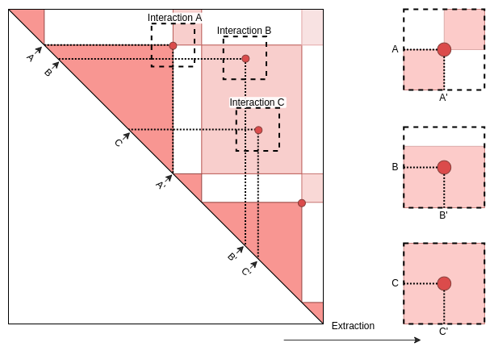

### Interactions defined with GInteraction or Pairs GRanges.

In extracted matrices, the middle of Y axis corresponds to the center of the first element and interact with the center of second element in the middle of X axis.

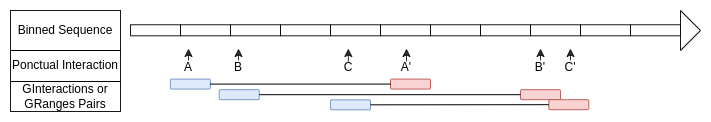

```r
interactions_PFmatrix.lst <- ExtractSubmatrix(
    feature.gn         = interactions.gni,
    hic.cmx_lst        = HiC_Ctrl.cmx_lst,
    referencePoint.chr = "pf",
    matriceDim.num     = 41
    )
```

### Interactions defined with GRanges.

The middle of Y axis corresponds to the start of the range and interact with the middle of X axis which corresponds with the end of the ranges.

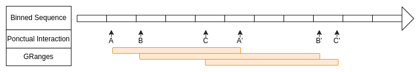

```r
domains_PFmatrix.lst <- ExtractSubmatrix(
    feature.gn         = TADs_Domains.gnr,
    hic.cmx_lst        = HiC_Ctrl.cmx_lst,
    referencePoint.chr = "pf",
    matriceDim.num     = 41
    )
```

## Case 2: Interactions around genomic regions or domains.

In this case, extracted matrices are resized and scaled in order to fit all regions to the same number of bins.

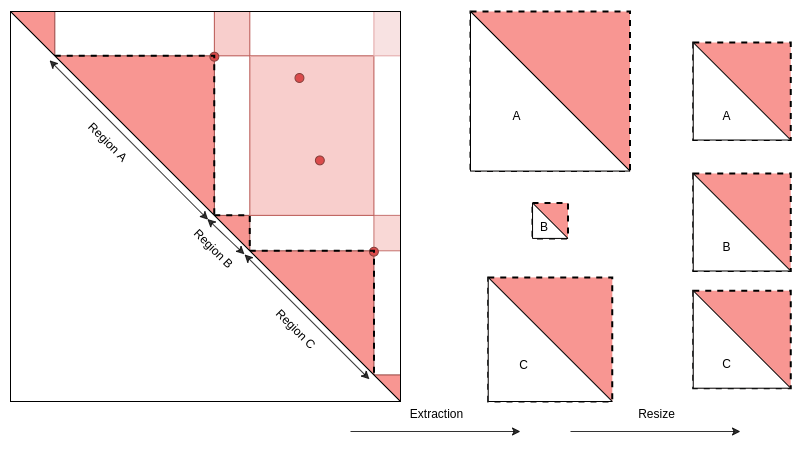

### Regions defined with GInteraction object or Pairs GRanges

The region’s start is defined by the center of the first element and the region’s end by the center of the second element.

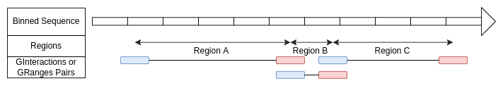

```r
interactions_RFmatrix_ctrl.lst  <- ExtractSubmatrix(
    feature.gn         = interactions.gni,
    hic.cmx_lst        = HiC_Ctrl.cmx_lst,
    res.num            = NULL,
    referencePoint.chr = "rf",
    matriceDim.num     = 101
    )
```

### Regions defined with GRanges

The regions are directly defined by the ranges of GRanges object.

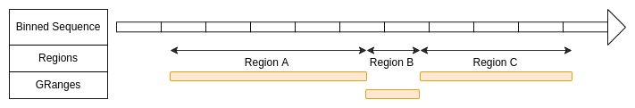

```r
domains_RFmatrix.lst <- ExtractSubmatrix(
    feature.gn         = TADs_Domains.gnr,
    hic.cmx_lst        = HiC_Ctrl.cmx_lst,
    referencePoint.chr = "rf",
    matriceDim.num     = 101,
    cores.num          = 1,
    verbose.bln        = FALSE
    )
```

## Case 3: Interactions along the diagonal.

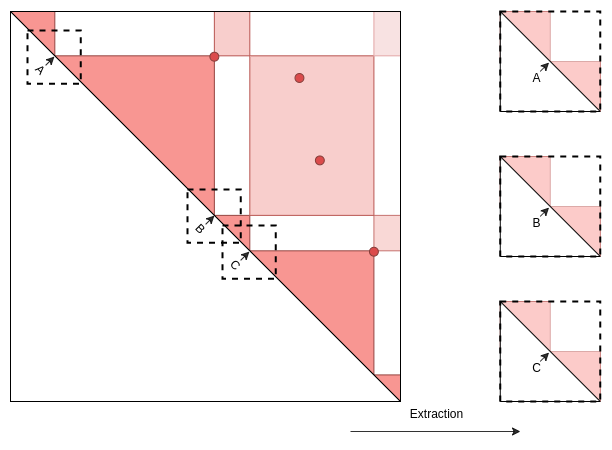

### Example with TAD:

Step 1: generate a GRanges object of TAD boundaries by concatenating starts and ends of TADs.

```r
domains_Border.gnr <- c(
        GenomicRanges::resize(TADs_Domains.gnr, 1, "start"),
        GenomicRanges::resize(TADs_Domains.gnr, 1,  "end" )
) |>
sort()
```

Step 2: Filter and reduce TAD boundaries GRanges object according to HiC resolution (binSize) + Store TAD names.

```r
domains_Border_Bin.gnr <- BinGRanges(
    gRange.gnr  = domains_Border.gnr,
    binSize.num = binSize.num,
    verbose.bln = FALSE
    )
domains_Border_Bin.gnr$subname <- domains_Border_Bin.gnr$name
domains_Border_Bin.gnr$name    <- domains_Border_Bin.gnr$bin
```

```r
domains_Border_Bin.gnr
```

Now we have a GRanges object. And for the exemples below we will need the same informations but in an GInteraction object.

```r
domains_Border_Bin.gni <- InteractionSet::GInteractions(domains_Border_Bin.gnr,domains_Border_Bin.gnr)
```

**View**

| First seq | First start | First end | First name | First score | First class | First bin | First subname | Second seq | Second start | Second end | Second name | Second score | Second class | Second bin | Second subname |
| --- | --- | --- | --- | --- | --- | --- | --- | --- | --- | --- | --- | --- | --- | --- | --- |
| 2L | 73001 | 74000 | 2L:74 | 3 | active | 2L:74 | Tad_1 | 2L | 73001 | 74000 | 2L:74 | active | 3 | 2L:74 | Tad_1 |
| 2L | 94001 | 95000 | 2L:95 | 3, 8 | active | 2L:95 | Tad_1, Tad_2 | 2L | 94001 | 95000 | 2L:95 | active | 3, 8 | 2L:95 | Tad_1, Tad_2 |
| 2L | 102001 | 103000 | 2L:103 | 8 | active | 2L:103 | Tad_2, Tad_3 | 2L | 102001 | 103000 | 2L:103 | active | 8 | 2L:103 | Tad_2, Tad_3 |

### Ponctual interactions defined with GRanges

Here the start and the end of each ranges are in a same bin.

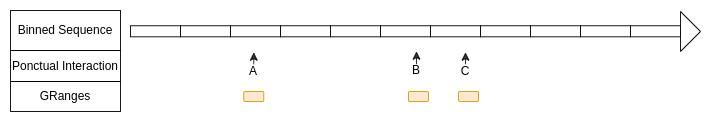

```r
border_PFmatrix.lst <- ExtractSubmatrix(
    feature.gn         = domains_Border_Bin.gnr,
    hic.cmx_lst        = HiC_Ctrl.cmx_lst,
    referencePoint.chr = "pf",
    matriceDim.num     = 101
)
```

### Ponctual interactions defined with GInteractions

Here the first element (blue on scheme) is in the same bin as the second (red on scheme).

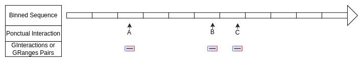

```r
border_PFmatrix.lst <- ExtractSubmatrix(
    feature.gn         = domains_Border_Bin.gni,
    hic.cmx_lst        = HiC_Ctrl.cmx_lst,
    referencePoint.chr = "pf",
    matriceDim.num     = 101
)
```

## Tips

1. If `res.num` is null, the function heritates the resolution `hic.cmx_lst` attributes.
2. referencePoint.chr is automatically set as “pf” if every anchors and baits are on the same bin (Case of Ex: Extraction of submatrices around TAD boundaries).

# Filtrations

The modularity of the workflow allows the user to filter interactions, pairs or extracted submatrices at any step of the analysis process. FilterInteractions() function takes as input a GInteraction object or a list of submatrices, a list defining targets to filter and a selection function defining how target elements will be filtered.

## Target list definition:

Target list must have a particular structure. First it is a named list. Each name of each element must be the name of column in the GInteraction that you want filter (or in the attributes “interactions” of the matrices list you want filter. Then each element must be a character list to match to this column or a function that will test each row in the column and return a bolean.

```r
structureTarget.lst <- list(
    first_colname_of_GInteraction  = c("value"),
    second_colname_of_GInteraction = function(eachElement){min_th<value && value<max_th}
    )
```

Interactions, pairs or extracted submatrices are filtered by metadata elements inherited from GRanges objects used in SearchPairs(). Those metadata are stored in the attributes of the submatrices list and are accessible as follow:

```r
attributes(interactions_RFmatrix_ctrl.lst)$interactions
names(S4Vectors::mcols(attributes(interactions_RFmatrix_ctrl.lst)$interactions))
```

**View**

| Ranges Names | Ranges First seq | Ranges First start | Ranges First end | Ranges Second seq | Ranges Second start | Ranges Second end | Metadata Interaction name | Metadata Interaction constraint | Metadata Interaction distance | Metadata Interaction orientation | Metadata Interaction submatrix.name | Metadata Anchor name | Metadata Anchor bin | Metadata Anchor Beaf.name | Metadata Anchor Beaf.score | Metadata Anchor Beaf.bln | Metadata Bait name | Metadata Bait bin | Metadata Bait Tss.name | Metadata Bait Tss.class | Metadata Bait Tss.bln |
| --- | --- | --- | --- | --- | --- | --- | --- | --- | --- | --- | --- | --- | --- | --- | --- | --- | --- | --- | --- | --- | --- |
| 2L:74_2L:77 | 2L | 73001 | 74000 | 2L | 76001 | 77000 | 2L:74_2L:77 | Tad_1 | 3000 | TRUE | 2L:74_2L:77 | 2L:74:Tad_1 | 2L:74 | Beaf32_8 | 205 | TRUE | 2L:77:Tad_1 | 2L:77 | FBgn0031214 | inactive | TRUE |
| 2L:115_2L:107 | 2L | 114001 | 115000 | 2L | 106001 | 107000 | 2L:115_2L:107 | Tad_3 | 8000 | FALSE | 2L:107_2L:115 | 2L:115:Tad_3 | 2L:115 | Beaf32_14 | 1707 | TRUE | 2L:107:Tad_3 | 2L:107 | FBgn0026…. | active | TRUE |
| 2L:121_2L:107 | 2L | 120001 | 121000 | 2L | 106001 | 107000 | 2L:121_2L:107 | Tad_3 | 14000 | FALSE | 2L:107_2L:121 | 2L:121:Tad_3 | 2L:121 | Beaf32_15 | 484 | TRUE | 2L:107:Tad_3 | 2L:107 | FBgn0026…. | active | TRUE |
| 2L:121_2L:117 | 2L | 120001 | 121000 | 2L | 116001 | 117000 | 2L:121_2L:117 | Tad_3 | 4000 | FALSE | 2L:117_2L:121 | 2L:121:Tad_3 | 2L:121 | Beaf32_15 | 484 | TRUE | 2L:117:Tad_3 | 2L:117 | FBgn0031219 | active | TRUE |
| 2L:274_2L:268 | 2L | 273001 | 274000 | 2L | 267001 | 268000 | 2L:274_2L:268 | Tad_10 | 6000 | FALSE | 2L:268_2L:274 | 2L:274:Tad_10 | 2L:274 | Beaf32_39 | 210 | TRUE | 2L:268:Tad_10 | 2L:268 | FBgn0031239 | inactive | TRUE |
| 2L:278_2L:268 | 2L | 277001 | 278000 | 2L | 267001 | 268000 | 2L:278_2L:268 | Tad_10 | 10000 | FALSE | 2L:268_2L:278 | 2L:278:Tad_10 | 2L:278 | Beaf32_41 | 1641 | TRUE | 2L:268:Tad_10 | 2L:268 | FBgn0031239 | inactive | TRUE |
| 2L:274_2L:279 | 2L | 273001 | 274000 | 2L | 278001 | 279000 | 2L:274_2L:279 | Tad_10 | 5000 | TRUE | 2L:274_2L:279 | 2L:274:Tad_10 | 2L:274 | Beaf32_39 | 210 | TRUE | 2L:279:Tad_10 | 2L:279 | FBgn0086855 | active | TRUE |
| 2L:306_2L:320 | 2L | 305001 | 306000 | 2L | 319001 | 320000 | 2L:306_2L:320 | Tad_13 | 14000 | TRUE | 2L:306_2L:320 | 2L:306:Tad_13 | 2L:306 | Beaf32_48 | 52 | TRUE | 2L:320:Tad_13 | 2L:320 | FBgn0031248 | inactive | TRUE |
| 2L:471_2L:422 | 2L | 470001 | 471000 | 2L | 421001 | 422000 | 2L:471_2L:422 | Tad_17 | 49000 | FALSE | 2L:422_2L:471 | 2L:471:Tad_17 | 2L:471 | Beaf32_62 | 37 | TRUE | 2L:422:Tad_17 | 2L:422 | FBgn0031253 | active | TRUE |
| 2L:472_2L:422 | 2L | 471001 | 472000 | 2L | 421001 | 422000 | 2L:472_2L:422 | Tad_17 | 50000 | FALSE | 2L:422_2L:472 | 2L:472:Tad_17 | 2L:472 | Beaf32_62 | 37 | TRUE | 2L:422:Tad_17 | 2L:422 | FBgn0031253 | active | TRUE |

### Example of target list:

In this example, Pairs will be filtered on anchor.Beaf.name, bait.Tss.name, name (which correpond to submatrix IDs) and distance. The aim of the example is to filter Pairs or submatrices that have: 1. “Beaf32_8” and “Beaf32_15” in **anchor.Beaf.name** 2. “FBgn0031214” and “FBgn0005278” in **bait.Tss.name**  
3. **distance** exactly equal to 14000 or 3000  
And to exclude Pairs or submatrices that have: 4. “2L:74_2L:77” in **name**

```r
target.lst <- list(
    anchor.Beaf.name = c("Beaf32_8","Beaf32_15"),
    bait.Tss.name    = c("FBgn0031214","FBgn0005278"),
    name             = c("2L:74_2L:77"),
    distance         = function(columnElement){
        return(14000==columnElement || columnElement == 3000)
        }
    )
```

## Selection Function definition:

The selection function defines which operations (union(), intersect(), setdiff()…) are done to filter the set of Pairs with target elements. For more operation examples, see *Selection function tips and examples* section.

### Example of selection function according to the example target

Following the example case defined in target.lst

```r
selection.fun = function(){
    Reduce(intersect, list(anchor.Beaf.name, bait.Tss.name ,distance) ) |>
    setdiff(name)
    }
```

## Filtration with selection

### Example of GInteraction object filtration

With a GInteraction object as input, FilterInteractions() will return the indices of filtered elements.

With the target.lst and selection.fun defined above:

```r
FilterInteractions(
    interarctions.gni = attributes(interactions_RFmatrix_ctrl.lst)$interactions,
    target.lst        = target.lst,
    selection.fun     = selection.fun
    )
```

```
#> [1] 3
```

### Example of Matrices list filtration

With a matrices list as input, FilterInteractions() will return the filtered matrices list, with updated attributes.

With the target.lst and selection.fun defined above:

```r
filtred_interactions_RFmatrix_ctrl.lst <- FilterInteractions(
    matrices.lst  = interactions_RFmatrix_ctrl.lst,
    target.lst    = target.lst,
    selection.fun = selection.fun
    )
```

## Specific case 1: Only one target and no selection

For example, we want to filter the top 100 first elements, so we target the 100 first names

```r
first100_target.lst = list(
    submatrix.name = names(interactions_RFmatrix_ctrl.lst)[1:100]
    )
```

### GInteraction filtration

```r
FilterInteractions(
    interarctions.gni = attributes(interactions_RFmatrix_ctrl.lst)$interactions,
    target.lst        = first100_target.lst,
    selection.fun     = NULL
    ) |> head()
```

```
#> submatrix.name1 submatrix.name2 submatrix.name3 submatrix.name4 submatrix.name5
#>               1               2               3               4               5
#> submatrix.name6
#>               6
```

### Matrices list filtration

```r
first100_interactions_RFmatrix_ctrl.lst <- FilterInteractions(
    matrices.lst  = interactions_RFmatrix_ctrl.lst,
    target.lst    = first100_target.lst,
    selection.fun = NULL
    )
attributes(first100_interactions_RFmatrix_ctrl.lst)$interactions
```

```
#> GInteractions object with 100 interactions and 15 metadata columns:
#>                     seqnames1           ranges1     seqnames2           ranges2
#>                         <Rle>         <IRanges>         <Rle>         <IRanges>
#>         2L:74_2L:77        2L       73001-74000 ---        2L       76001-77000
#>       2L:115_2L:107        2L     114001-115000 ---        2L     106001-107000
#>       2L:121_2L:107        2L     120001-121000 ---        2L     106001-107000
#>       2L:121_2L:117        2L     120001-121000 ---        2L     116001-117000
#>       2L:274_2L:268        2L     273001-274000 ---        2L     267001-268000
#>                 ...       ...               ... ...       ...               ...
#>   2L:12515_2L:12498        2L 12514001-12515000 ---        2L 12497001-12498000
#>   2L:12516_2L:12498        2L 12515001-12516000 ---        2L 12497001-12498000
#>   2L:12515_2L:12508        2L 12514001-12515000 ---        2L 12507001-12508000
#>   2L:12516_2L:12508        2L 12515001-12516000 ---        2L 12507001-12508000
#>   2L:12515_2L:12509        2L 12514001-12515000 ---        2L 12508001-12509000
#>                     |              name  constraint  distance orientation
#>                     |       <character> <character> <integer>   <logical>
#>         2L:74_2L:77 |       2L:74_2L:77       Tad_1      3000        TRUE
#>       2L:115_2L:107 |     2L:115_2L:107       Tad_3      8000       FALSE
#>       2L:121_2L:107 |     2L:121_2L:107       Tad_3     14000       FALSE
#>       2L:121_2L:117 |     2L:121_2L:117       Tad_3      4000       FALSE
#>       2L:274_2L:268 |     2L:274_2L:268      Tad_10      6000       FALSE
#>                 ... .               ...         ...       ...         ...
#>   2L:12515_2L:12498 | 2L:12515_2L:12498     Tad_310     17000       FALSE
#>   2L:12516_2L:12498 | 2L:12516_2L:12498     Tad_310     18000       FALSE
#>   2L:12515_2L:12508 | 2L:12515_2L:12508     Tad_310      7000       FALSE
#>   2L:12516_2L:12508 | 2L:12516_2L:12508     Tad_310      8000       FALSE
#>   2L:12515_2L:12509 | 2L:12515_2L:12509     Tad_310      6000       FALSE
#>                        submatrix.name  anchor.bin      anchor.name    bait.bin
#>                           <character> <character>      <character> <character>
#>         2L:74_2L:77       2L:74_2L:77       2L:74      2L:74:Tad_1       2L:77
#>       2L:115_2L:107     2L:107_2L:115      2L:115     2L:115:Tad_3      2L:107
#>       2L:121_2L:107     2L:107_2L:121      2L:121     2L:121:Tad_3      2L:107
#>       2L:121_2L:117     2L:117_2L:121      2L:121     2L:121:Tad_3      2L:117
#>       2L:274_2L:268     2L:268_2L:274      2L:274    2L:274:Tad_10      2L:268
#>                 ...               ...         ...              ...         ...
#>   2L:12515_2L:12498 2L:12498_2L:12515    2L:12515 2L:12515:Tad_310    2L:12498
#>   2L:12516_2L:12498 2L:12498_2L:12516    2L:12516 2L:12516:Tad_310    2L:12498
#>   2L:12515_2L:12508 2L:12508_2L:12515    2L:12515 2L:12515:Tad_310    2L:12508
#>   2L:12516_2L:12508 2L:12508_2L:12516    2L:12516 2L:12516:Tad_310    2L:12508
#>   2L:12515_2L:12509 2L:12509_2L:12515    2L:12515 2L:12515:Tad_310    2L:12509
```

[output cut: 27 more lines]

```
#>                        <logical>
#>         2L:74_2L:77         TRUE
#>       2L:115_2L:107         TRUE
#>       2L:121_2L:107         TRUE
#>       2L:121_2L:117         TRUE
#>       2L:274_2L:268         TRUE
#>                 ...          ...
#>   2L:12515_2L:12498         TRUE
#>   2L:12516_2L:12498         TRUE
#>   2L:12515_2L:12508         TRUE
#>   2L:12516_2L:12508         TRUE
#>   2L:12515_2L:12509         TRUE
#>   -------
#>   regions: 429 ranges and 0 metadata columns
#>   seqinfo: 2 sequences from an unspecified genome
```

**Warning!** A selection of some matrices removes attributes.

```r
attributes(interactions_RFmatrix_ctrl.lst[1:20])$interactions
```

## Specific case 2: Sampling

```r
nSample.num = 3
set.seed(123)
target.lst = list(name=sample(attributes(interactions_RFmatrix_ctrl.lst)$interactions$name,nSample.num))
```

### GInteraction sampling

```r
FilterInteractions(
    interarctions.gni = attributes(interactions_RFmatrix_ctrl.lst)$interactions,
    target.lst        = target.lst,
    selection.fun     = NULL
    )
```

```
#> name1 name2 name3
#>    14   179   195
```

### Matrices list sampling

```r
sampled_interactions_RFmatrix_ctrl.lst <- FilterInteractions(
    matrices.lst  = interactions_RFmatrix_ctrl.lst,
    target.lst    = target.lst,
    selection.fun = NULL
    )
attributes(sampled_interactions_RFmatrix_ctrl.lst)$interactions
```

```
#> GInteractions object with 3 interactions and 15 metadata columns:
#>                     seqnames1           ranges1     seqnames2           ranges2
#>                         <Rle>         <IRanges>         <Rle>         <IRanges>
#>     2L:1178_2L:1174        2L   1177001-1178000 ---        2L   1173001-1174000
#>   2L:21574_2L:21492        2L 21573001-21574000 ---        2L 21491001-21492000
#>     2R:5672_2R:5653        2R   5671001-5672000 ---        2R   5652001-5653000
#>                     |              name  constraint  distance orientation
#>                     |       <character> <character> <integer>   <logical>
#>     2L:1178_2L:1174 |   2L:1178_2L:1174      Tad_35      4000       FALSE
#>   2L:21574_2L:21492 | 2L:21574_2L:21492     Tad_486     82000       FALSE
#>     2R:5672_2R:5653 |   2R:5672_2R:5653     Tad_513     19000       FALSE
#>                        submatrix.name  anchor.bin      anchor.name    bait.bin
#>                           <character> <character>      <character> <character>
#>     2L:1178_2L:1174   2L:1174_2L:1178     2L:1178   2L:1178:Tad_35     2L:1174
#>   2L:21574_2L:21492 2L:21492_2L:21574    2L:21574 2L:21574:Tad_486    2L:21492
#>     2R:5672_2R:5653   2R:5653_2R:5672     2R:5672  2R:5672:Tad_513     2R:5653
#>                            bait.name anchor.Beaf.score anchor.Beaf.name
#>                          <character>         <numeric>           <list>
#>     2L:1178_2L:1174   2L:1174:Tad_35               921       Beaf32_130
#>   2L:21574_2L:21492 2L:21492:Tad_486               529      Beaf32_1349
#>     2R:5672_2R:5653  2R:5653:Tad_513                99      Beaf32_1462
#>                     anchor.Beaf.bln bait.Tss.class bait.Tss.name bait.Tss.bln
#>                           <logical>         <list>        <list>    <logical>
#>     2L:1178_2L:1174            TRUE         active   FBgn0031318         TRUE
#>   2L:21574_2L:21492            TRUE       inactive   FBgn0053837         TRUE
#>     2R:5672_2R:5653            TRUE         active   FBgn0033028         TRUE
#>   -------
#>   regions: 429 ranges and 0 metadata columns
#>   seqinfo: 2 sequences from an unspecified genome
```

## Specific case 3: FilterInteractions() without selection function

Without any selection function, FilterInteractions() will return all indices corresponding to each target in the list. Then, the indices of interest can be selected in a second step. For the examples we take the folowing targets:

```r
target.lst <- list(
    anchor.Beaf.name = c("Beaf32_8","Beaf32_15"),
    bait.Tss.name    = c("FBgn0031214","FBgn0005278"),
    name             = c("2L:74_2L:77"),
    distance         = function(columnElement){
        return(14000==columnElement || columnElement == 3000)
        }
    )
```

### GInteraction filtration

```r
FilterInteractions(
    interarctions.gni = attributes(interactions_RFmatrix_ctrl.lst)$interactions,
    target.lst        = target.lst,
    selection.fun     = NULL
    ) |> str()
```

```
#> List of 4
#>  $ anchor.Beaf.name: int [1:3] 1 3 4
#>  $ bait.Tss.name   : int [1:3] 1 2 3
#>  $ name            : int 1
#>  $ distance        : int [1:25] 1 3 8 24 38 49 63 65 80 102 ...
```

### Matrices list filtration

```r
FilterInteractions(
    matrices.lst      = interactions_RFmatrix_ctrl.lst,
    target.lst        = target.lst,
    selection.fun     = NULL
    ) |>
str()
```

```
#> List of 4
#>  $ anchor.Beaf.name: int [1:3] 1 3 4
#>  $ bait.Tss.name   : int [1:3] 1 2 3
#>  $ name            : int 1
#>  $ distance        : int [1:25] 1 3 8 24 38 49 63 65 80 102 ...
```

## Tips

1. Filter a GInteraction object allows to cross the selected index.
2. Filter a matrices list without selection is better than filter the interaction attributes of the matrices list

### Selection function tips and examples:

```r
a <- c("A","B","D","G")
b <- c("E","B","C","G")
c <- c("A","F","C","G")
```

1. Which is common to A, B and C

```r
Reduce(intersect, list(a,b,c)) |> sort()
```

```
#> [1] "G"
```

```r
intersect(a,b) |> intersect(c) |> sort()
```

```
#> [1] "G"
```

2. Which is in A and/or B and/or C

```r
Reduce(union, list(a,b,c)) |> sort()
```

```
#> [1] "A" "B" "C" "D" "E" "F" "G"
```

```r
union(a,b) |> union(c) |> sort()
```

```
#> [1] "A" "B" "C" "D" "E" "F" "G"
```

3. Which is only in A

```r
Reduce(setdiff,list(a,b,c)) |> sort()
```

```
#> [1] "D"
```

```r
setdiff(a,b) |> setdiff(c) |> sort()
```

```
#> [1] "D"
```

4. Which is common in A with B, and not in C

```r
intersect(a,b) |> setdiff(c) |> sort()
```

```
#> [1] "B"
```

5. What is common in A with B, plus all that is present in C

```r
intersect(a,b) |> union(c) |> sort()
```

```
#> [1] "A" "B" "C" "F" "G"
```

6. What is common in C with all elements present in A and B

```r
union(a,b) |> intersect(c) |> sort()
```

```
#> [1] "A" "C" "G"
```

7. Everything that is present in A and B but not in C

```r
union(a,b) |> setdiff(c) |> sort()
```

```
#> [1] "B" "D" "E"
```

8. Which is present only once

```r
d <- c(a,b,c)
setdiff(d,d[duplicated(d)]) |> sort()
```

```
#> [1] "D" "E" "F"
```

# Orientation

ExtractSubmatrix() returns submatrices orientated according to 5’->3’ orientation of the chromosome. In the case of heterotypic or asymetric pairs (anchor != bait), anchors and baits are thus mixed on Y and X axis of the matrices.

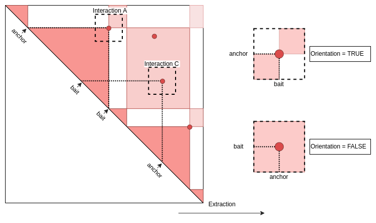

OrienteMatrix() function allows to force all matrices to be orientated in a way that anchors will be systematically on Y axis and baits on X axis.

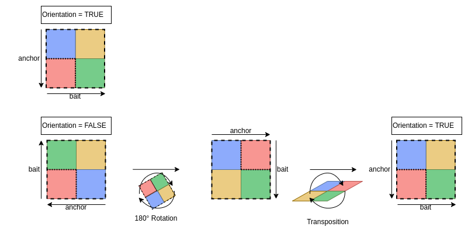

## Acces orientation information

First, lets look how two matrices are oriented (column orientation of metadata of the interactions attribute). Below we can see that the first matrix is correctly oriented (value is TRUE) but not the second one.

```r
attributes(first100_interactions_RFmatrix_ctrl.lst)$interactions$orientation
```

```
#>   [1]  TRUE FALSE FALSE FALSE FALSE FALSE  TRUE  TRUE FALSE FALSE FALSE FALSE
#>  [13]  TRUE FALSE  TRUE  TRUE FALSE FALSE FALSE  TRUE  TRUE  TRUE FALSE FALSE
#>  [25] FALSE FALSE FALSE  TRUE FALSE FALSE FALSE FALSE  TRUE  TRUE FALSE FALSE
#>  [37] FALSE FALSE FALSE FALSE FALSE FALSE FALSE  TRUE  TRUE  TRUE  TRUE  TRUE
#>  [49]  TRUE FALSE FALSE  TRUE  TRUE  TRUE  TRUE FALSE FALSE FALSE FALSE  TRUE
#>  [61]  TRUE FALSE FALSE FALSE  TRUE FALSE  TRUE  TRUE  TRUE FALSE FALSE  TRUE
#>  [73] FALSE FALSE FALSE FALSE  TRUE  TRUE  TRUE FALSE FALSE FALSE  TRUE  TRUE
#>  [85]  TRUE FALSE  TRUE  TRUE  TRUE FALSE  TRUE  TRUE  TRUE  TRUE FALSE FALSE
#>  [97] FALSE FALSE FALSE FALSE
```

1. The 13th matrice is well oriented, i.e. the **anchor Beaf is in Y axis** and the **bait TSS in X axis**
2. The 14th matrice is not well oriented, i.e. the **bait TSS is in Y axis** and the **anchor Beaf in X axis**

## Orientation on matrices list

```r
oriented_first100_interactions_RFmatrix_ctrl.lst <- OrienteMatrix(first100_interactions_RFmatrix_ctrl.lst)
```

```
#> 58 matrices are oriented
```

## Orientation on only one matrice.

The function could also oriente only one matrix but in this case there is no attribute verification so you can oriente a matrix that don’t need orentation.

```r
orientedMatrix.mtx <- OrienteMatrix(first100_interactions_RFmatrix_ctrl.lst[[1]])
```

# Quantifications

GetQuantif() function takes as input a list of submatrices and returns a vector of contact frequencies on a given area, compute with a given function:

## Basic quantifications

the `GetQuantif` function has some default area and function (see `Genomic2DTK::GetQuantif`).

1. **area**: Key word defining on which area the values are extracted in each matrices.
2. **operation** Key word defining which operation is done on extracted values for each matrices.

Example: Interactions values on the centered 3x3 square centred, averaged after removing all zeros.

```r
center.num <- GetQuantif(
    matrices.lst  = oriented_first100_interactions_RFmatrix_ctrl.lst,
    area.fun      = "center",
    operation.fun = "mean"
    )
```

## Custom functions

The `GetQuantif` function also takes custom **area** and **operation** in parameter.

1. **area**: function defining on which submatrix coordinates the values are extracted in each matrices.
2. **operation** function defining which operation is done on extracted values for each matrices.

Example: Interactions values on the matrice.mtx[33:35,67:69] area, averaged after removing all zeros.

```r
GetQuantif(
    matrices.lst  = oriented_first100_interactions_RFmatrix_ctrl.lst,
    area.fun      = function(matrice.mtx){matrice.mtx[33:35,67:69]},
    operation.fun = function(area.mtx){
        area.mtx[which(area.mtx==0)]<-NA;
        return(mean(area.mtx,na.rm=TRUE))
        }
    ) |>
c() |>
unlist() |>
head()
```

```
#>   2L:74_2L:77 2L:115_2L:107 2L:121_2L:107 2L:121_2L:117 2L:274_2L:268
#>     1.1964916     0.7079941     0.3850699     0.5802793     0.1114877
#> 2L:278_2L:268
#>     0.1286555
```

## Particular cases:

### Values naming

By default, returned values are named with submatrix ID. If name.chr is set with an element metadata column name from GInteraction attributes, values are returned values are named according to this element.

Example: Named quantifications with `anchor.Beaf.name`

```r
namedCenter.num <- GetQuantif(
    matrices.lst  = oriented_first100_interactions_RFmatrix_ctrl.lst,
    area.fun      = "center",
    operation.fun = "mean",
    name.chr      = "anchor.Beaf.name"
    )
```

Note that changing submatrix ID for other names can create names duplicates:

Example: The 46th matrix is correspond to two Beaf32 peaks, i.e. it has two anchor.Beaf.name

|  | name | anchor.Beaf.name |
| --- | --- | --- |
| 45 | 2L:5909_2L:5941 | Beaf32_415 |
| 46 | 2L:5944_2L:5968 | Beaf32_4…. |
| 47 | 2L:5945_2L:5968 | Beaf32_418 |
| 48 | 2L:6051_2L:6069 | Beaf32_430 |
| 49 | 2L:6066_2L:6069 | Beaf32_432 |
| 50 | 2L:6084_2L:6071 | Beaf32_435 |

By consequence, the value in center.num is duplicated in namedCenter.num

```r
unlist(c(center.num))[45:50]
```

```
#> 2L:5909_2L:5941 2L:5944_2L:5968 2L:5945_2L:5968 2L:6051_2L:6069 2L:6066_2L:6069
#>       0.6376167       0.6754207       0.6832946       0.6930854       1.2542497
#> 2L:6084_2L:6071
#>       0.8629411
```

```r
unlist(c(namedCenter.num))[45:51]
```

```
#> Beaf32_415 Beaf32_417 Beaf32_418 Beaf32_418 Beaf32_430 Beaf32_432 Beaf32_435
#>  0.6376167  0.6754207  0.6754207  0.6832946  0.6930854  1.2542497  0.8629411
```

Duplicated value index are stored in attributes.

```r
attributes(center.num)$duplicated
```

```r
attributes(namedCenter.num)$duplicated
```

```
#> [1] 47
```

### One value extraction

```r
GetQuantif(
    matrices.lst  = oriented_first100_interactions_RFmatrix_ctrl.lst,
    area.fun      = function(matrice.mtx){matrice.mtx[5,5]},
    operation.fun = function(area.mtx){area.mtx}
    ) |>
head()
```

```
#>   2L:74_2L:77 2L:115_2L:107 2L:121_2L:107 2L:121_2L:117 2L:274_2L:268
#>     0.5192703     0.3471995     0.7177761     0.5917856     0.5535116
#> 2L:278_2L:268
#>     0.6732039
```

### Area extraction

```r
GetQuantif(
    matrices.lst  = oriented_first100_interactions_RFmatrix_ctrl.lst,
    area.fun      = function(matrice.mtx){matrice.mtx[4:6,4:6]},
    operation.fun = function(area){area}
    ) |>
head()
```

```
#>   2L:74_2L:77 2L:115_2L:107 2L:121_2L:107 2L:121_2L:117 2L:274_2L:268
#>     0.5401282            NA            NA     0.5621180     0.5192703
#> 2L:278_2L:268
#>            NA
```

If is null operation.fun return values of the selected area without NA.

```r
GetQuantif(
    matrices.lst  = oriented_first100_interactions_RFmatrix_ctrl.lst,
    area.fun      = function(matrice.mtx){matrice.mtx[4:6,4:6]},
    operation.fun = NULL
    ) |>
head()
```

```
#>   2L:74_2L:77 2L:115_2L:107 2L:121_2L:107 2L:121_2L:117 2L:274_2L:268
#>     0.5401282     0.5621180     0.5192703     0.5841077     0.5451626
#> 2L:278_2L:268
#>     0.5062174
```

## Tips

1. To print quantifications use `c` function to avoid the attributes printing.
2. When you select area if is null `operation.fun` returns values of the selected area without NA.

# Aggregations

Aggregation() function takes as input a list of submatrices and returns an aggregated matrix using a user defined aggregation function.

## One sample aggregation

### Basic aggregation

Aggregation() function has some default aggregation functions like `sum`, `mean` or `median` (see `Genomic2DTK::Aggregation`)

```r
agg_sum.mtx <- Aggregation(
    matrices.lst = oriented_first100_interactions_RFmatrix_ctrl.lst,
    agg.fun      = "sum",
    rm0.bln      = FALSE
    )
```

### Custom aggregation

Defining a custom aggregation function, example with mean function removing NA:

```r
agg_mean.mtx <- Aggregation(
    matrices.lst = oriented_first100_interactions_RFmatrix_ctrl.lst,
    agg.fun      = function(x){mean(x,na.rm=TRUE)}
    )
```

## Two samples differential aggregation

Aggregation() function can take as input two list of submatrices from two samples or conditions and returns a differential aggregated matrix. Two ways to obtain differential aggregation are applied, first is by assessing differences on each individual pairs of matrices then aggregate the differences; second is by aggregating matrices and assess differences on aggregated matrices.

### Preparation of matrices list

1. Preparation of Control matrices list condition  
   **Filtration**

```r
first100_target.lst = list(
    submatrix.name = names(interactions_RFmatrix_ctrl.lst)[1:100]
    )
first100_interactions_RFmatrix_ctrl.lst <- FilterInteractions(
    matrices.lst  = interactions_RFmatrix_ctrl.lst,
    target.lst    = first100_target.lst,
    selection.fun = NULL
    )
```

**Orientation**

```r
oriented_first100_interactions_RFmatrix_ctrl.lst <- OrienteMatrix(first100_interactions_RFmatrix_ctrl.lst)
```

```r
interactions_RFmatrix.lst  <- ExtractSubmatrix(
    feature.gn         = interactions.gni,
    hic.cmx_lst        = HiC_HS.cmx_lst,
    referencePoint.chr = "rf",
    matriceDim.num     = 101
    )
```

**Filtration**

```r
first100_interactions_RFmatrix.lst <- FilterInteractions(
    matrices.lst  = interactions_RFmatrix.lst,
    target.lst    = first100_target.lst,
    selection.fun = NULL
    )
```

**Orientation**

```r
oriented_first100_interactions_RFmatrix.lst <- OrienteMatrix(first100_interactions_RFmatrix.lst)
```

```
#> 58 matrices are oriented
```

### Aggregate

```r
diffAggreg.mtx <- Aggregation(
    ctrlMatrices.lst    = oriented_first100_interactions_RFmatrix_ctrl.lst,
    matrices.lst        = oriented_first100_interactions_RFmatrix.lst,
    minDist             = NULL,
    maxDist             = NULL,
    agg.fun             = "mean",
    rm0.bln             = FALSE,
    diff.fun            = "substraction",
    scaleCorrection.bln = TRUE,
    correctionArea.lst  =  list(
        i = c(1:30),
        j = c(72:101)
        ),
    statCompare.bln = TRUE)
```

## Tips

1. When you perform a one sample aggregation, you could use any of `matrices.lst` or `ctrlMatrices.lst` parameters
2. If `rm0.bln` is `TRUE` all zeros in matrices list are replace by NA.
3. It is possible to filter submatrices list by minimal or maximal distance during the aggregation function.
4. Since statistical test is highly memory consumming, it is recommended not to apply it each time.
5. Aggregation() on one sample keeps attributes of the matrices list and add some news:
   - totalMatrixNumber: total number of matrices.
   - filteredMatrixNumber: number of matrices after distance filtering.
   - minimalDistance: minimal distance between anchor and bait.
   - maximalDistance: maximal distance between anchor and bait.
   - aggregationMethod: The function apply to obtain the aggregation.
   - zeroRemoved: A Boolean that indicate if zeros have been replaced by NA.
6. Aggregation() on two samples adds additional attributes:
   - correctedFact: The value that is add to the condition to delete some noise. It’s compute by the median difference between condition and control in an background area (e.g upper right corner in matrices).
   - matrices: The list of matrices.
     - agg: Aggregation of the condition.
     - aggCtrl: Aggregation of the control.
     - aggCorrected: Aggregation of the condition corrected with correctedFact.
     - aggDelta: the difference between the aggregated matrix of the condition and the aggregated matrix of the control.
     - aggCorrectedDelta: the difference between the aggregated matrix of the condition corrected with correctedFact and the aggregated matrix of the control.

# Aggregations plots

## Preparation of aggregated matrices

1. Control aggregation with no orientation

```r
aggreg.mtx <- Aggregation(
        ctrlMatrices.lst=interactions_RFmatrix_ctrl.lst,
        agg.fun="mean",
        rm0.bln=FALSE
)
```

2. Control aggregation with orientation

```r
oriented_interactions_RFmatrix_ctrl.lst <- OrienteMatrix(interactions_RFmatrix_ctrl.lst)
```

```
#> 168 matrices are oriented
```

```r
orientedAggreg.mtx <- Aggregation(
        ctrlMatrices.lst=oriented_interactions_RFmatrix_ctrl.lst,
        agg.fun="mean",
        rm0.bln=FALSE
)
```

3. Differential aggregation

```r
oriented_interactions_RFmatrix.lst <- OrienteMatrix(interactions_RFmatrix.lst)
```

```
#> 168 matrices are oriented
```

```r
diffAggreg.mtx <- Aggregation(
        ctrlMatrices.lst    = oriented_interactions_RFmatrix_ctrl.lst,
        matrices.lst        = oriented_interactions_RFmatrix.lst,
        minDist             = NULL,
        maxDist             = NULL,
        agg.fun             = "mean",
        rm0.bln             = FALSE,
        diff.fun            = "log2+1",
        scaleCorrection.bln = TRUE,
        correctionArea.lst  = list( i=c(1:30) , j=c(72:101) ),
        statCompare.bln     = TRUE
)
```

## Plots

### Simple aggregation plot:

#### With no orientation

ggAPA() function creates a ggplot object (ggplot2::geom_raster)

```r
ggAPA(
        apa.mtx   = aggreg.mtx,
        title.chr = "APA"
)
```

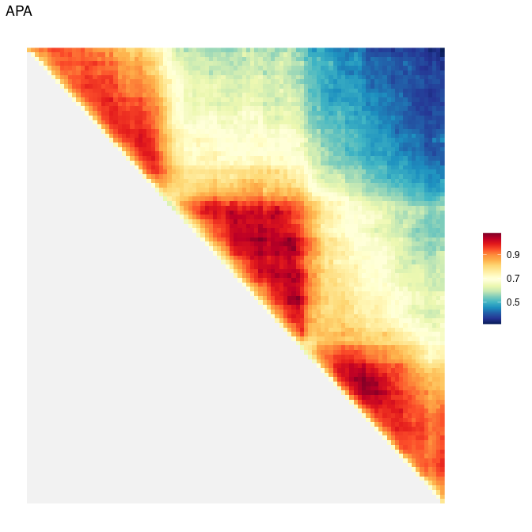

#### With Orientation

```r
ggAPA(
        apa.mtx   = orientedAggreg.mtx,
        title.chr = "APA"
)
```

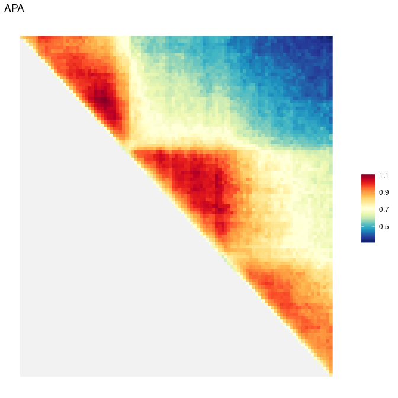

### Further visualisation parameters:

#### Trimming aggregated values for visualisation:

You could remove a percentage of value choose in upper tail, lower tail or both tails of the distribution.

```r
ggAPA(
        apa.mtx      = aggreg.mtx,
        title.chr    = "APA 30% trimmed on upper side",
        trimPrct.num = 30,
        bounds.chr   = "upper"
)
```

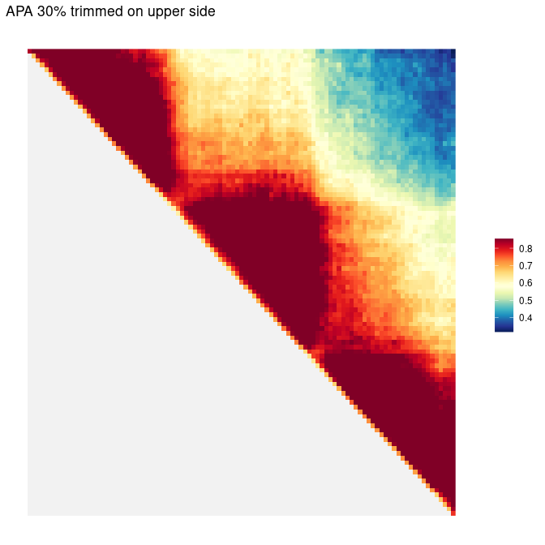

```r
ggAPA(
        apa.mtx      = aggreg.mtx,
        title.chr    = "APA 30% trimmed on upper side",
        trimPrct.num = 30,
        bounds.chr   = "lower"
)
```

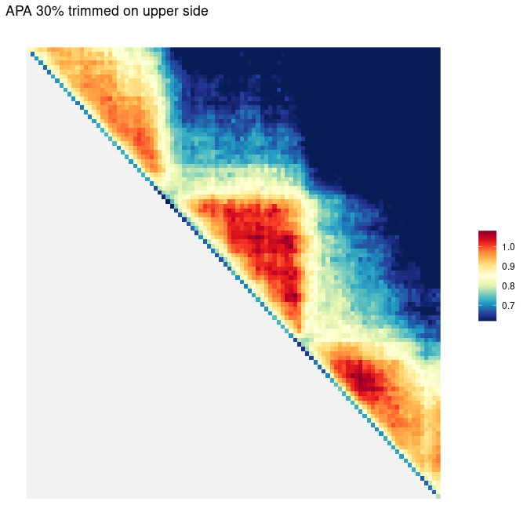

```r
ggAPA(
        apa.mtx      = aggreg.mtx,
        title.chr    = "APA 30% trimmed",
        trimPrct.num = 30,
        bounds.chr   = "both"
)
```

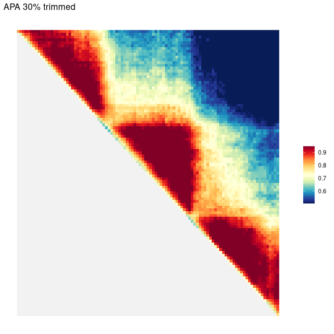